# Practice the ggplot2 Library

## Change the axes limit

To add a limit for x-axis and y-axis use “xlim(), ylim()” layers. For exapmle, limit x(carat) between 0,2 and y(price) between 0, 10000$

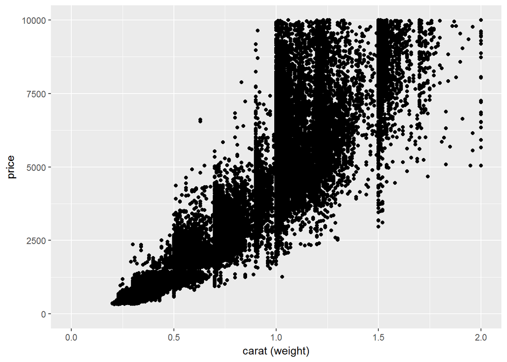

```r
#Note that this action can cause data loss in the plot
ggplot(diamonds, aes(x=carat, y=price)) + geom_point() + xlab("carat (weight)") + xlim(0,2) + ylim(0,10000)
```

## Usine log-scale

To put one of the axes in log scale, for example the y-axis, use “scale_y_log10()” layer

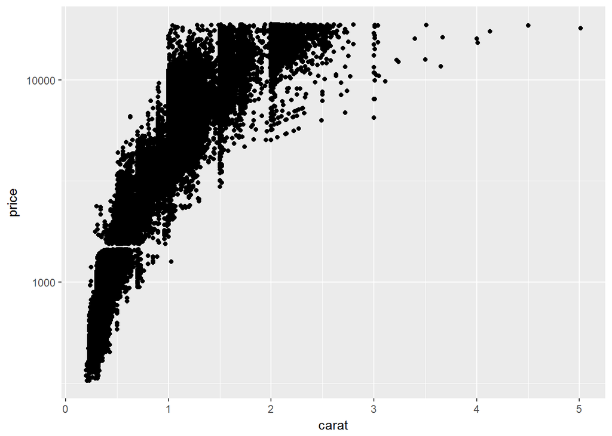

```r
ggplot(diamonds, aes(x=carat, y=price)) + geom_point() + scale_y_log10()
```

## Adding Additional Features To the Scatter Plot

### Point color

To add additional feature in the plot use **color**, for example add “clarity” feature

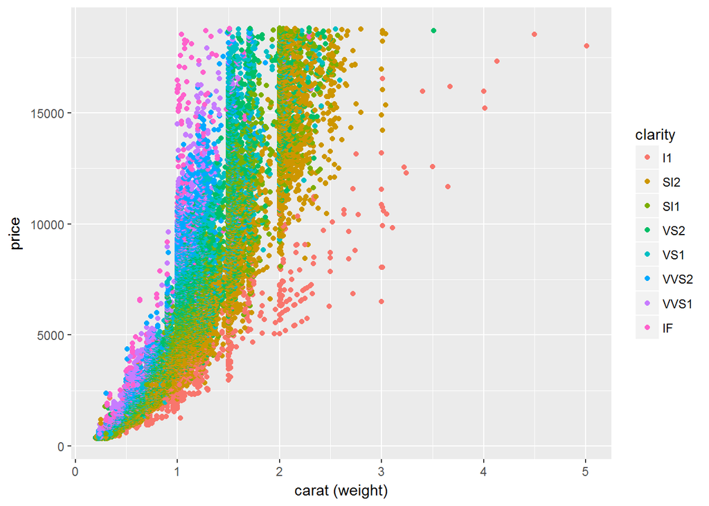

```r
ggplot(diamonds, aes(x=carat, y=price, color=clarity)) + geom_point() + xlab("carat (weight)")
```

## Point Shape

What about the “cut” feature, can we add it too…Yes by the point **shape**

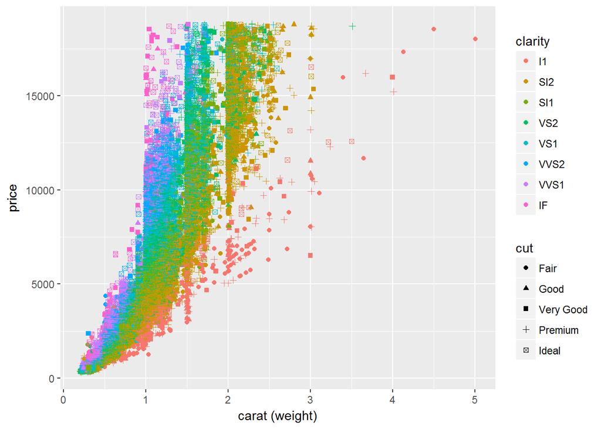

```r
ggplot(diamonds, aes(x=carat, y=price, color=clarity, shape=cut)) + geom_point() + xlab("carat (weight)")
```

### Point size

Or the point **size**, but as we can see, its not a good idea for this dense data

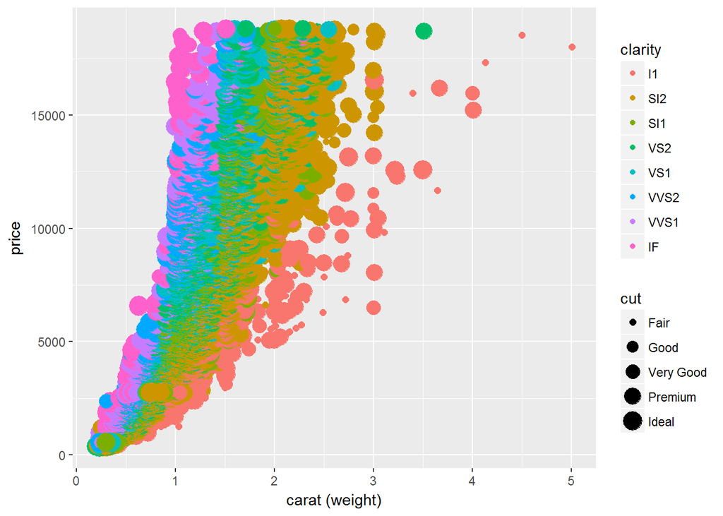

```r
ggplot(diamonds, aes(x=carat, y=price, color=clarity, size=cut)) + geom_point() + xlab("carat (weight)")
```

## General curve to represent the data

### Smooth Curve Representation

We can add a smooth curve (additional layer) to show the general trend of the data. Don’t forget, we do this by the (+) sign.

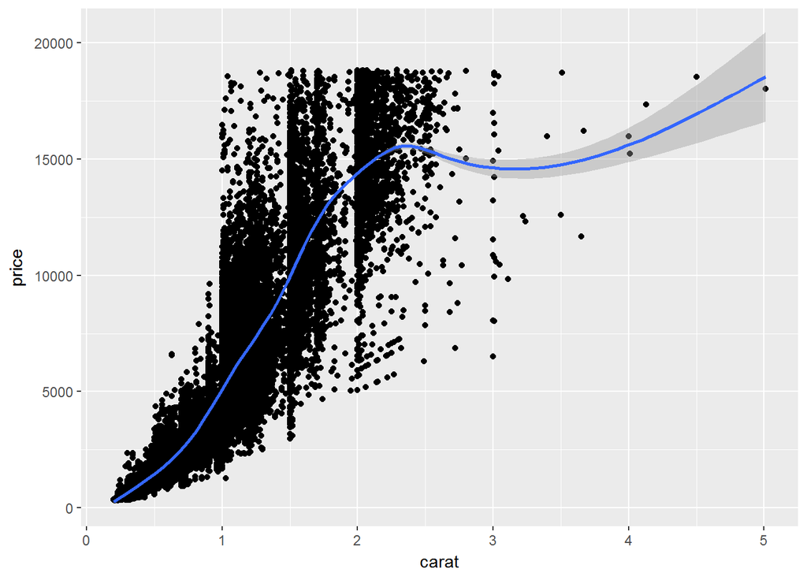

```r
# the gray area around the curve is the confidence interval.
#To turn it off we can turn off the standard error option in geo_smooth(next figure).
ggplot(diamonds, aes(x=carat, y=price)) + geom_point() + geom_smooth()
```

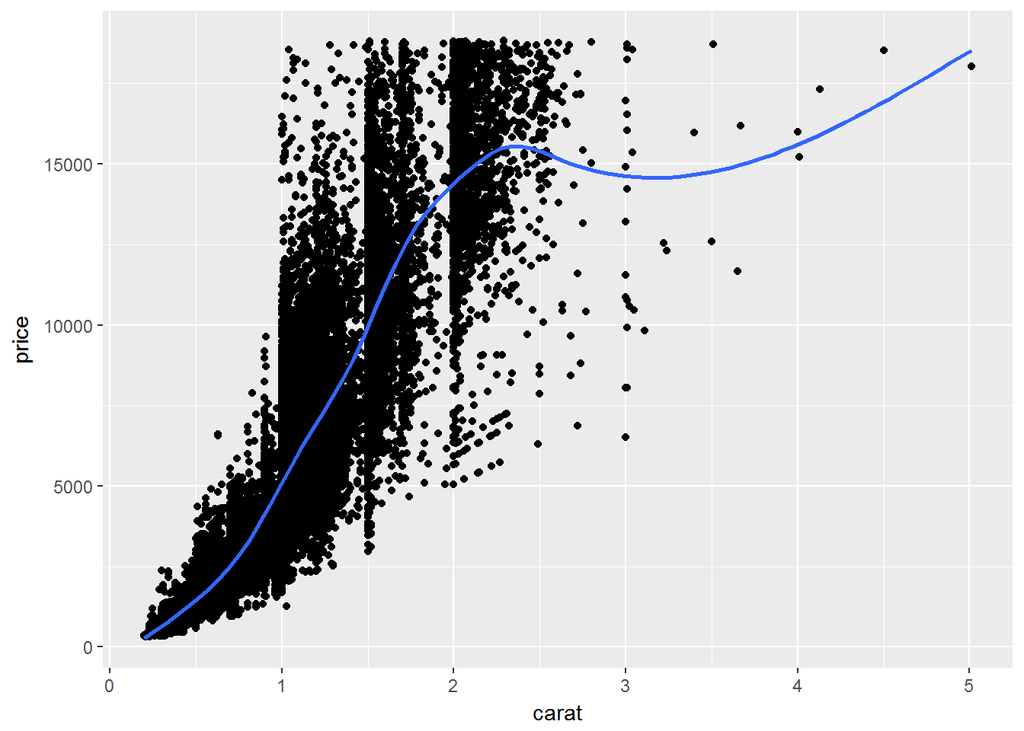

```r
# Remove the confidence area around the curve
ggplot(diamonds, aes(x=carat, y=price)) + geom_point() + geom_smooth(se=FALSE)
```

### Linear model Representation

We also can add the best fit line for that data, by changing the method that “geom_smooth” is using.

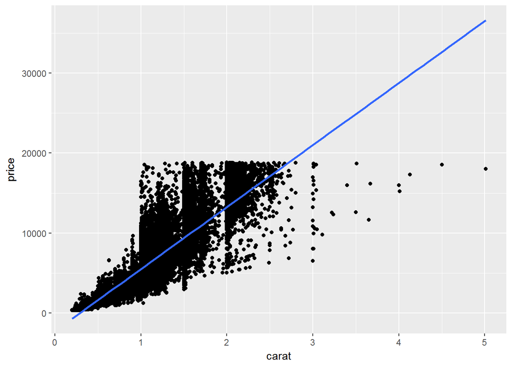

```r
ggplot(diamonds, aes(x=carat, y=price)) + geom_point() + geom_smooth(se=FALSE, method="lm")
```

### Divide the smooth curve wrt some feature

We can get a smooth curve that represnts the data with respect to a specific feature rather than a one curve for all the data. For example, get the data curves wrt clarity. To do that, add “color = clarity” in the “aes()”

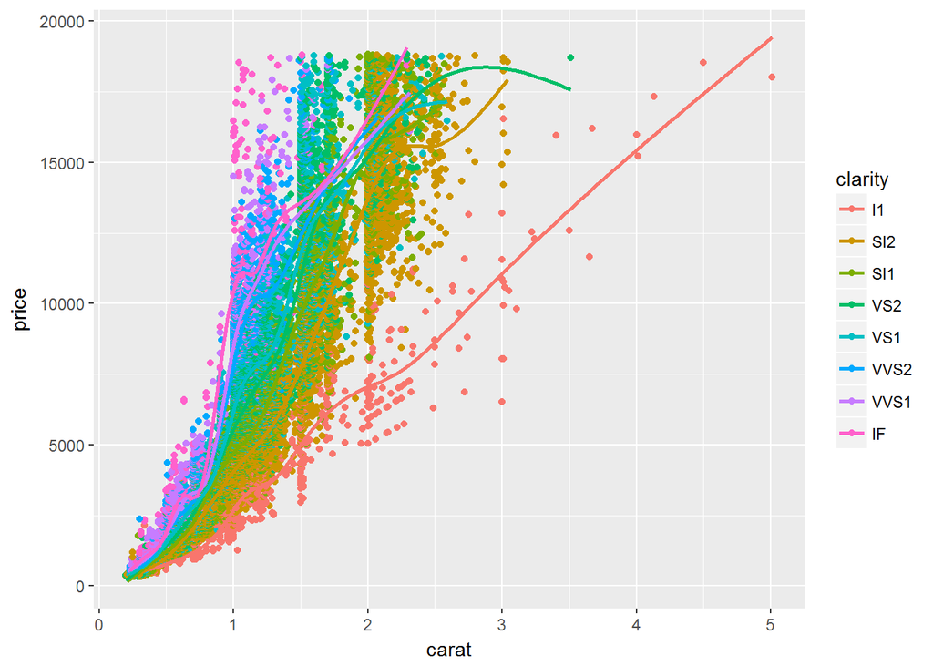

```r
ggplot(diamonds, aes(x=carat, y=price, color=clarity)) + geom_point() + geom_smooth(se=FALSE)
```

### Show the curves only

We can only show the curves layer without the scattered points, by simply removing the “geom_point()” layer.

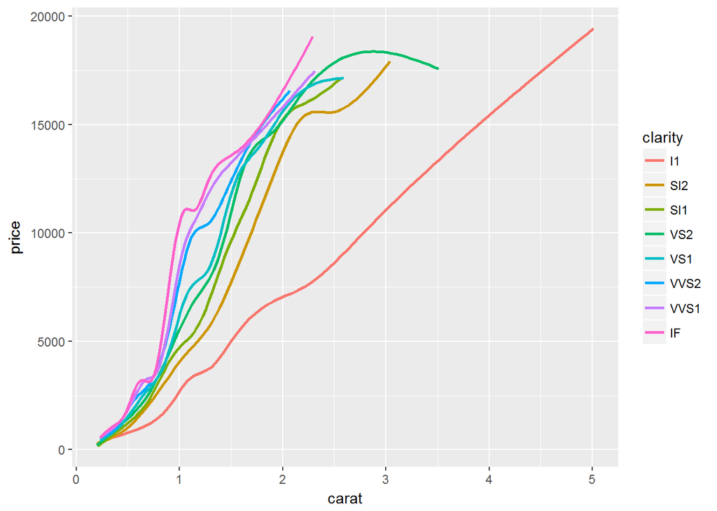

```r
ggplot(diamonds, aes(x=carat, y=price, color=clarity)) + geom_smooth(se=FALSE)
```

### Divide the linear models wrt some feature

We can do the same using lines ….

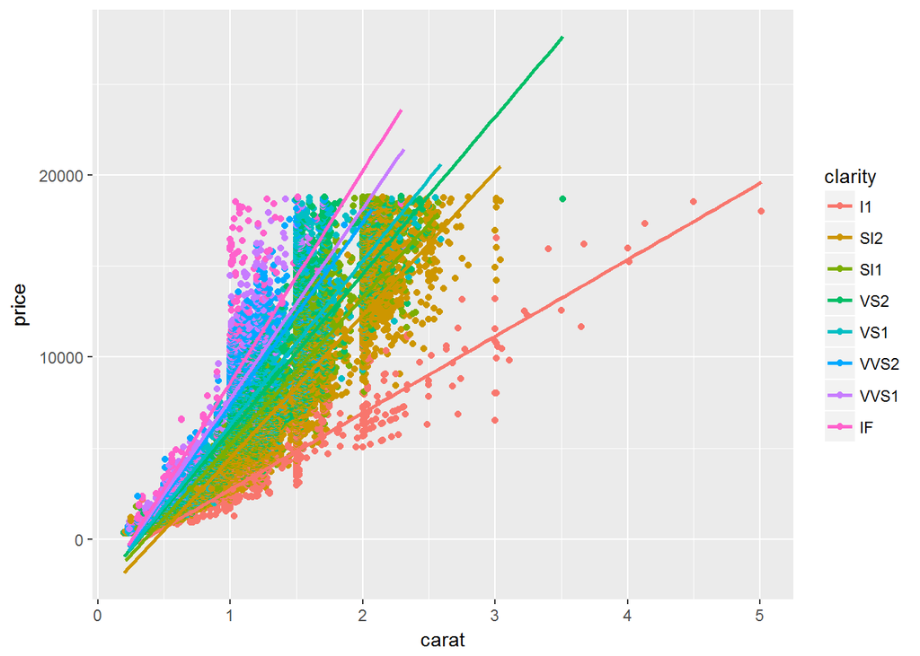

```r
ggplot(diamonds, aes(x=carat, y=price, color=clarity)) + geom_point() + geom_smooth(se=FALSE, method = "lm")
```

### Show the lines only

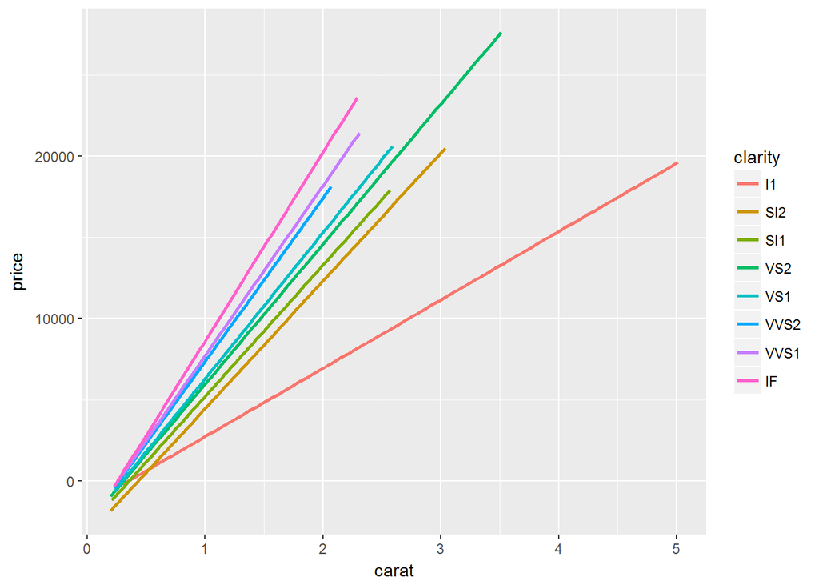

```r
ggplot(diamonds, aes(x=carat, y=price, color=clarity)) + geom_smooth(se=FALSE, method = "lm")
```

# 3- Using Faceting with Scatter plots

Faceting is to divide the plot into smaller ones wrt some attribute/feature. Back to the original scatter plot.

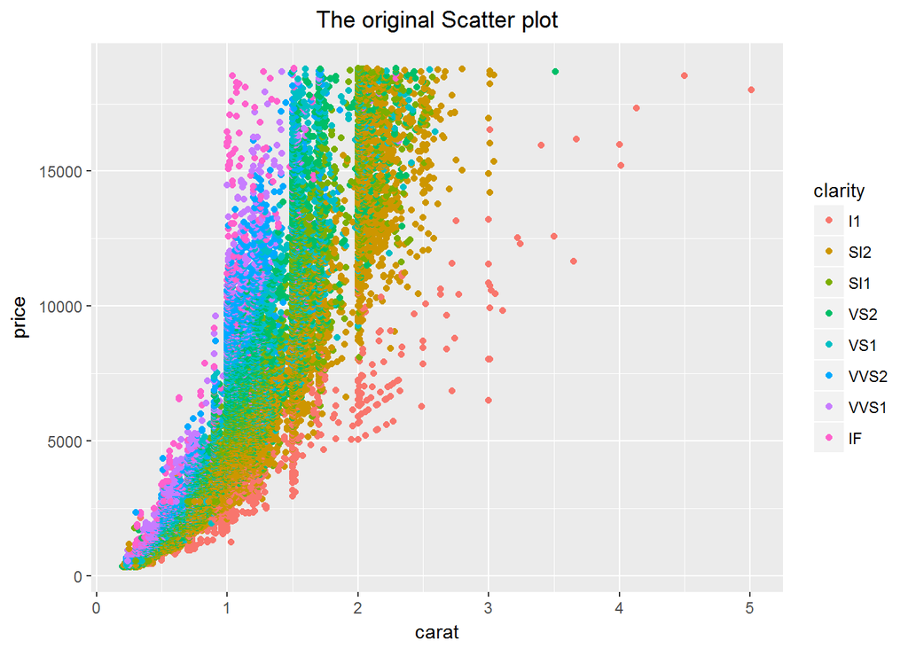

```r
ggplot(diamonds, aes(x=carat, y=price, color = clarity)) + geom_point() + ggtitle("The original Scatter plot") + theme(plot.title = element_text(hjust = 0.5))
```

## We can divide it into smaller scatter plots in terms of “clarity” by adding the “facet_wrap()” layer, and specifiny the feature that we want to use to divide the plot, in this case “~clarity”.

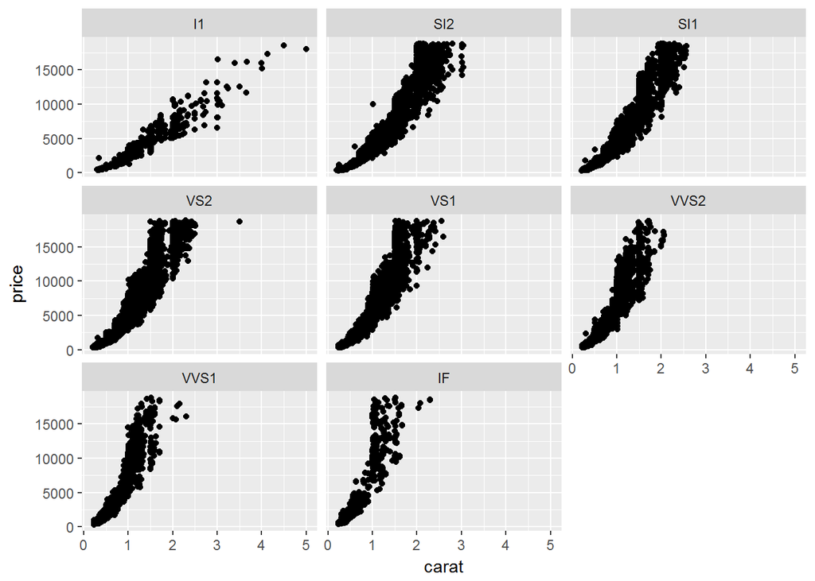

```r
ggplot(diamonds, aes(x=carat, y=price)) + geom_point() + facet_wrap(~clarity)
```

## We can also use scatter plot “color”, to visualize an additional feature.

For example, the diamond color “color” , takes values from J (worst) to D (best). Don’t get confused between the two “color”, one is the plot method, and the other is just a feature from the dataset.

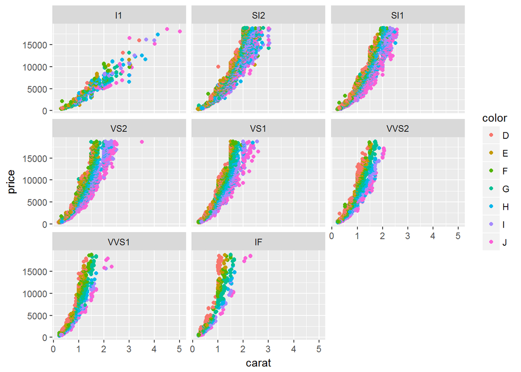

```r
ggplot(diamonds, aes(x=carat, y=price, color=color)) + geom_point() + facet_wrap(~clarity)
```

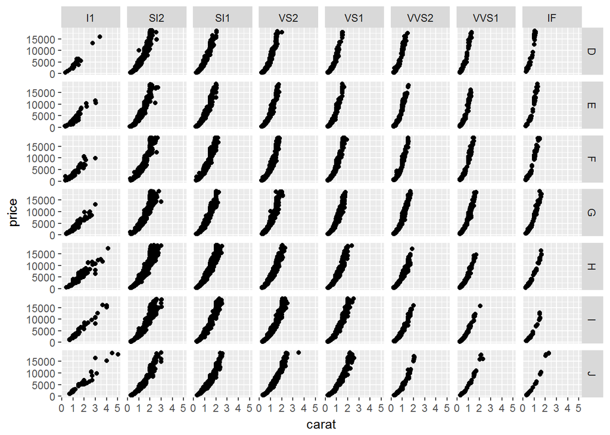

```r
ggplot(diamonds, aes(x=carat, y=price)) + geom_point() + facet_grid(color~clarity)
```

## We can also add the “cut” feature to this mega plot, do you know how….Yes, use color, or shape, or size for the scattered points. We will use “color”.

Note, this plot has “carat” on the x-axis, “price” on the y-axis, has 8*7 subplots to specify the different “clarities” and “colors”, also has a colored points to see the different “cuts”. 5 Features in one plot. Amazing ha.

[figure not shown]

```r
#to center the title use: theme(plot.title = element_text(hjust = 0.5))
ggplot(diamonds, aes(x=carat, y=price, color=cut)) + geom_point() + facet_grid(color~clarity)+ ggtitle("5 in 1 Plot") + theme(plot.title = element_text(hjust = 0.5))
```

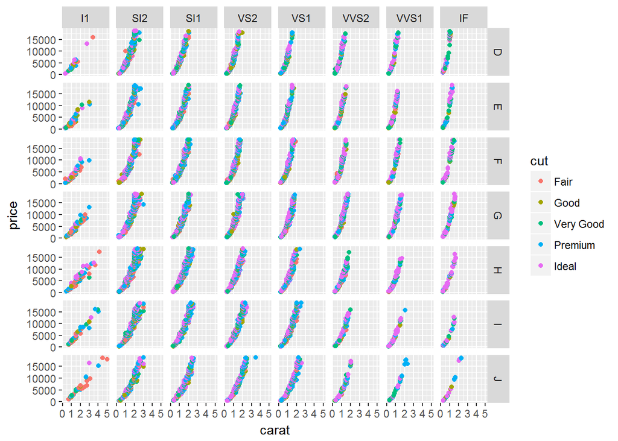

```r
ggplot(diamonds, aes(x=carat, y=price, color=cut)) + geom_point() + facet_grid(color~clarity)
```

# 4- Histograms

## We can plot a histogram for a single feature by adding “geom_histogram()” layer.

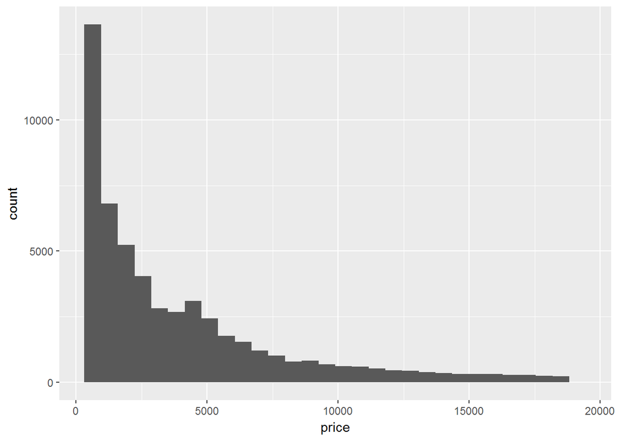

```r
#plot a histogram for the price feature, where the x-axis is th proce and the y-axis is the frequency "the count"
ggplot(diamonds, aes(x=price)) + geom_histogram()
```

## control the bin width using “binwidth” inside the “geom_histogram”

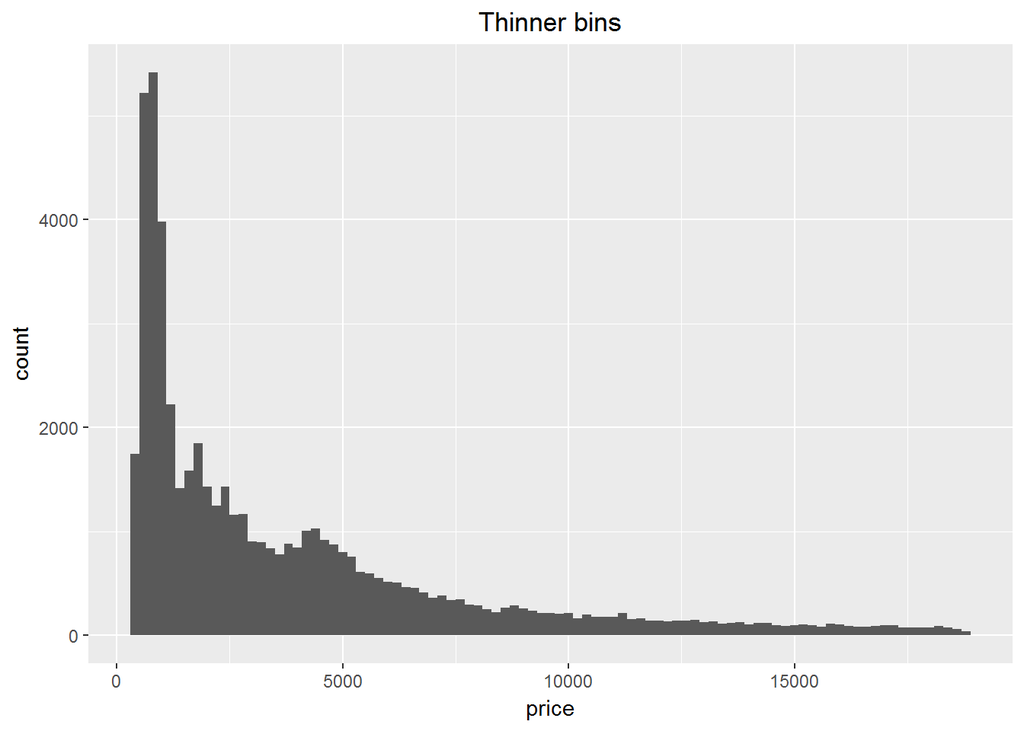

```r
ggplot(diamonds, aes(x=price)) + geom_histogram(binwidth = 200 ) + ggtitle("Thinner bins") + theme(plot.title = element_text(hjust = 0.5))
```

# 5- Using Faceting with Histograms

## We can divide the big histogram the represents the whole data into smaller ones with respect to some feature, using “facet_wrap(~ feature_name)”.

For example, we can divide the histogram above wrt “clarity”

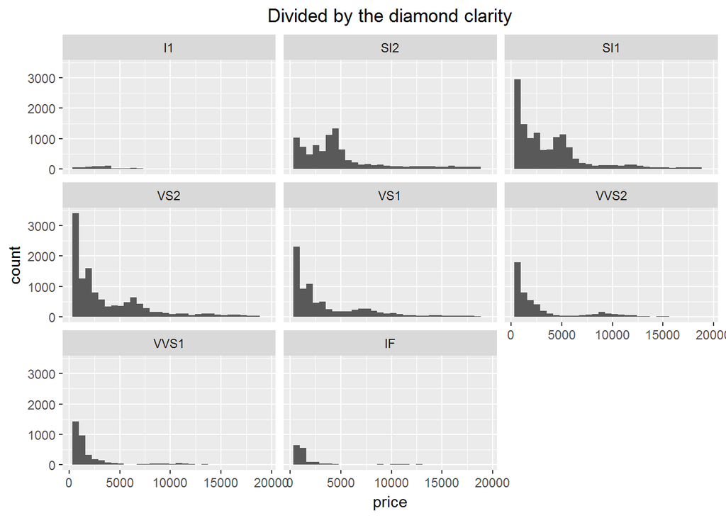

```r
ggplot(diamonds, aes(x=price)) + geom_histogram() + facet_wrap(~ clarity) + ggtitle("Divided by the diamond clarity") + theme(plot.title = element_text(hjust = 0.5))
```

## You can see in the previous figure that the “I1” histogram count is not clear (top left one) because we use the same scale in the y-axis. To change that we can add “free_y” option into the “facet_wrap()” layer.

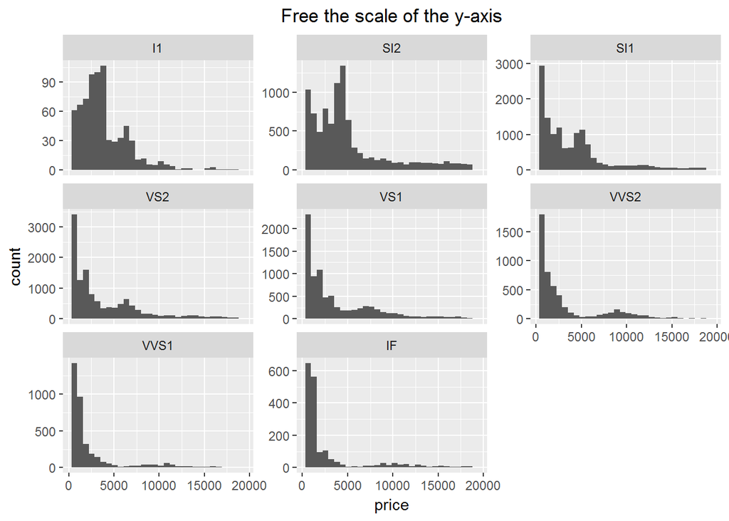

```r
ggplot(diamonds, aes(x=price)) + geom_histogram() + facet_wrap(~ clarity, scale="free_y") + ggtitle("Free the scale of the y-axis") + theme(plot.title = element_text(hjust = 0.5))
```

## Another cool thing to do is to make a STACK HISTOGRAM. we can fill the bins of the histogram with different colors to represent the distribution of other feature.

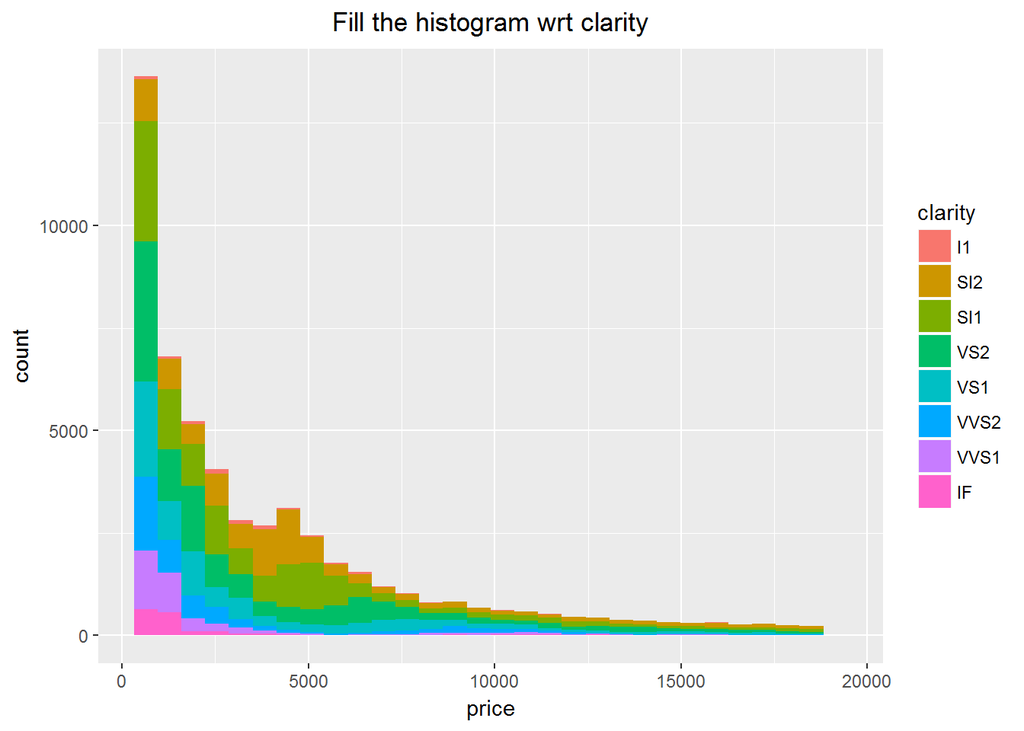

```r
ggplot(diamonds, aes(x=price, fill=clarity)) + geom_histogram() + ggtitle("Fill the histogram wrt clarity") + theme(plot.title = element_text(hjust = 0.5))
```

## We can get the density curve of the distribution by using “geom_density” layer instead of “geom_histogram”

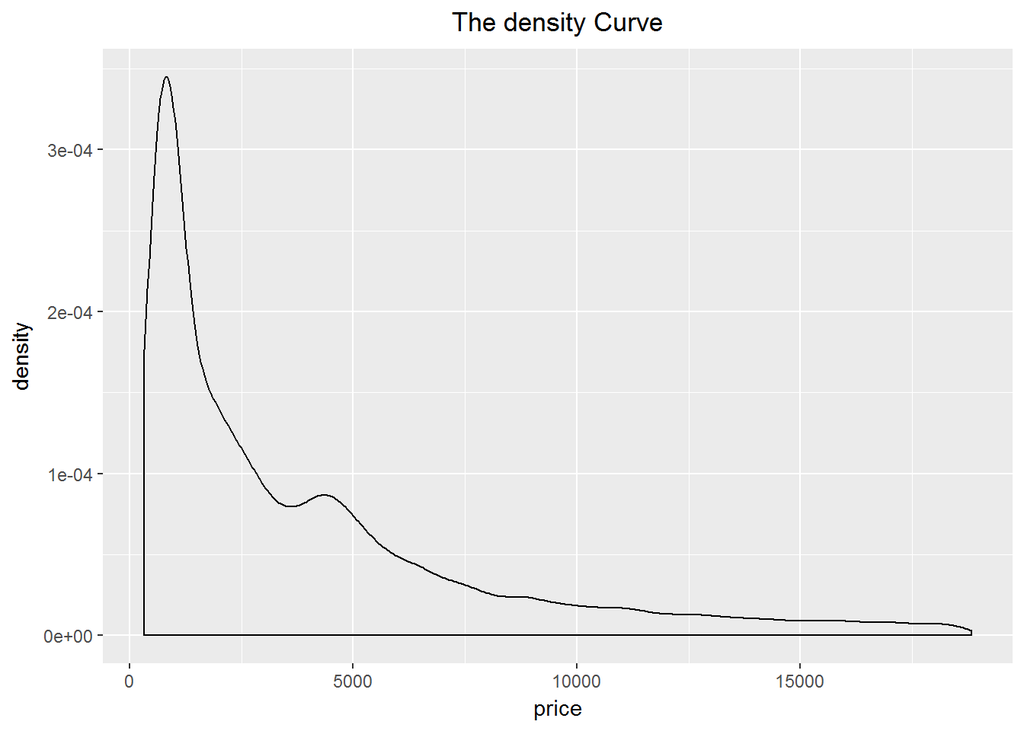

```r
ggplot(diamonds, aes(x=price)) + geom_density() + ggtitle("The density Curve") + theme(plot.title = element_text(hjust = 0.5))
```

## To compare multiple distributions wrt some feature, use “color=feature_name” in the “aes”

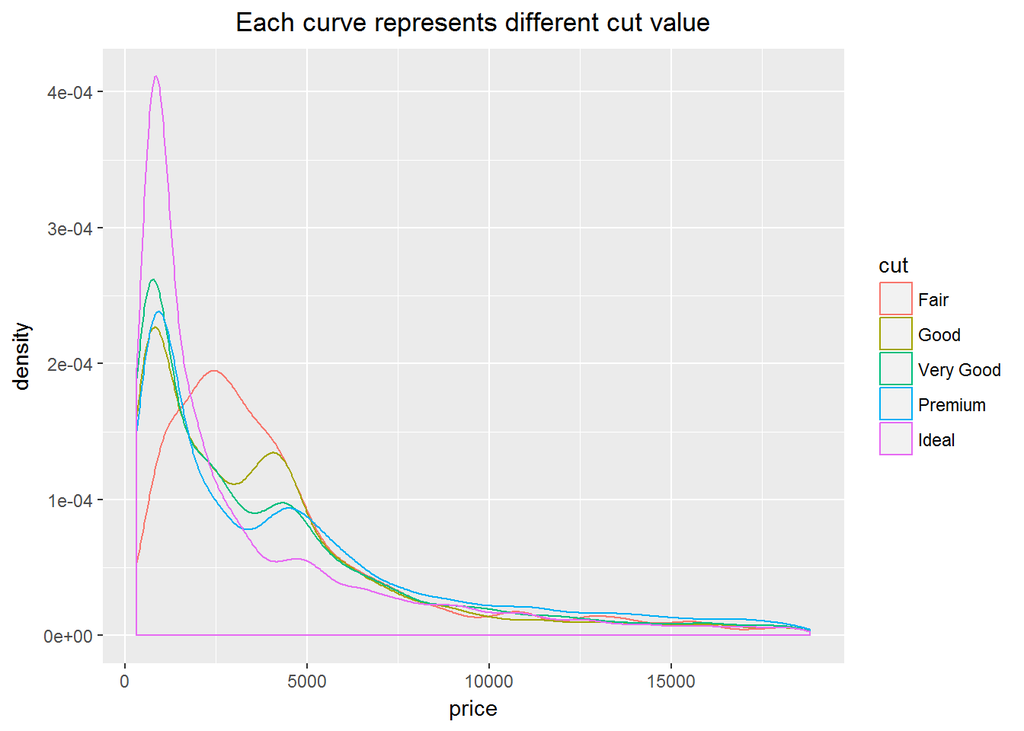

```r
ggplot(diamonds, aes(x=price, color=cut)) + geom_density() + ggtitle("Each curve represents different cut value") + theme(plot.title = element_text(hjust = 0.5))
```

## we can also divide put each curve into a separate plot.

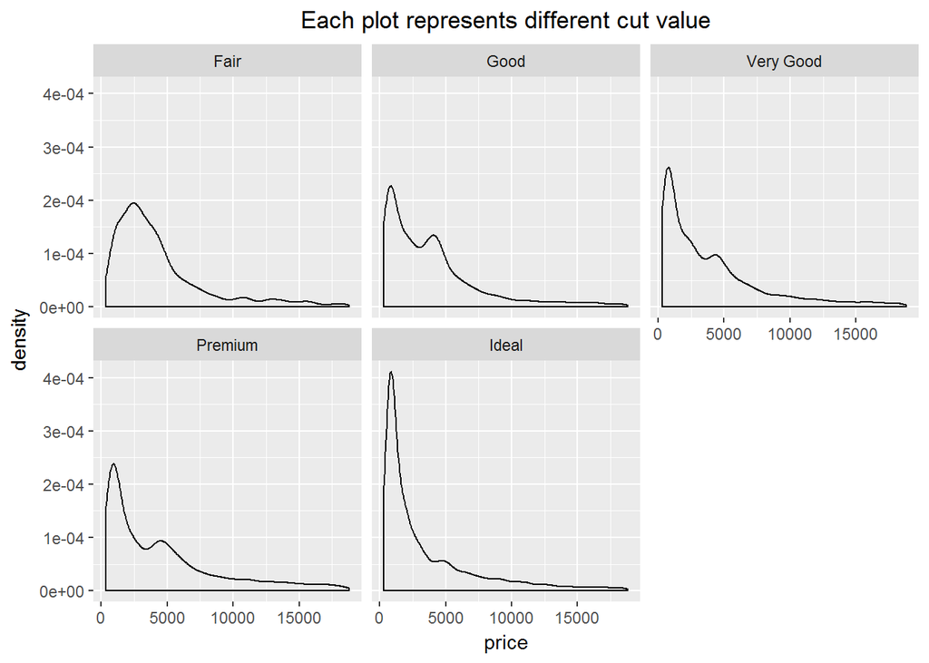

```r
ggplot(diamonds, aes(x=price)) + geom_density() + facet_wrap(~ cut) + ggtitle("Each plot represents different cut value") + theme(plot.title = element_text(hjust = 0.5))
```